# [CptS 215 Data Analytics Systems and Algorithms](https://piazza.com/wsu/fall2017/cpts215/home)

[Washington State University](https://wsu.edu)

[Gina Sprint](http://eecs.wsu.edu/~gsprint/)

## MA7 Graph Practice (50 pts)

Author: Nam Jun Lee

Date: December 4th, 2021

### Learner Objectives

At the conclusion of this micro assignment, participants should be able to:

- Implement/analyze graphs
- Traverse graphs

### Prerequisites

Before starting this micro assignment, participants should be able to:

- Write Markdown and code cells in Jupyter Notebook
- Perform algorithm analysis

### Acknowledgments

Content used in this assignment is based upon information in the following sources:

- [Data Structures: Abstraction and Design Using Java](https://www.wiley.com/en-us/Data+Structures%3A+Abstraction+and+Design+Using+Java%2C+3rd+Edition-p-9781119186526) by Koffman and Wolfgang
- [Miller and Ranum](https://runestone.academy/runestone/books/published/pythonds/Graphs/DiscussionQuestions.html)

## Overview and Requirements

For this micro assignment, you are going to download this Jupyter Notebook and answer the following questions. Your answer for a problem should be in a cell *immediately* after the problem cell. *Do not modify the problem cell.*

We are going to solve several problems related to graphs and their efficiency. This micro assignment includes conceptional questions and programming.

### Conceptual Questions (28 pts)

Solve the following problems and *justify* your answers:

```python
# insert image in jupyter notebook
from IPython.display import Image
```

1. (2 pts) Draw the graph corresponding to the following list of edges.

| from | to | cost |
| --- | --- | --- |
| 1 | 2 | 10 |
| 1 | 3 | 15 |
| 1 | 6 | 5 |
| 2 | 3 | 7 |
| 3 | 4 | 7 |
| 3 | 6 | 10 |
| 4 | 5 | 7 |
| 6 | 4 | 5 |
| 5 | 6 | 13 |

#### Question 1 Answer:

Draw the graph corresponding to the following list of edges.

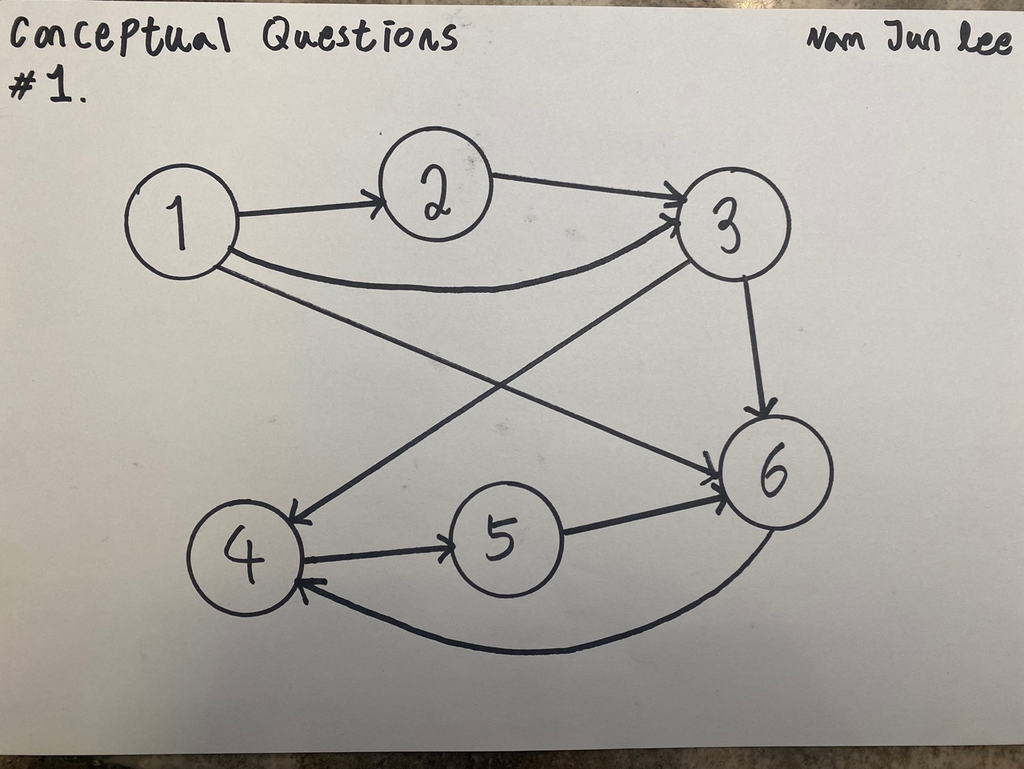

```python
Image("Q1.jpg")
```

2. (2 pts) Draw the graph corresponding to the following adjacency matrix:

[figure not shown]

(image from https://runestone.academy/runestone/books/published/pythonds/_images/adjMatEX.png)

#### Question 2 Answer:

Draw the graph corresponding to the following adjacency matrix:

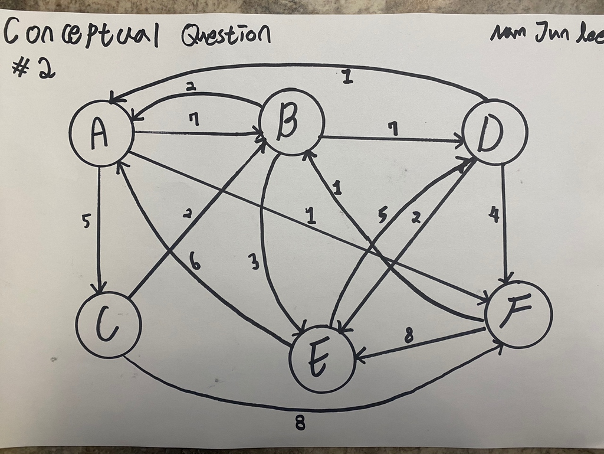

```python
Image("Q2.jpg")
```

3. For the following digraph:

[figure not shown]

```
A. (2 pts) List the vertices.
B. (2 pts) List the edges.
C. (2 pts) Does this graph contain any cycles?
D. (2 pts) Show the adjacency matrix.
E. (2 pts) Show the adjacency list.
```

#### Question 3 Answer:

1. Following digraph:
   1. List the vertices:  
      `V = {0, 1, 2, 3, 4, 5, 6, 7}`
   2. List the edges:  
      `E = {(0,1), (0,3), (0,5), (1,2), (2,4), (3,4), (4,7), (5,3), (5,6), (6,7)}`
   3. Does this graph contain any cycles?  
      A cycle refers to the path of a vertex and a corner that can start at the vertex and follow the path to its starting vertex.  
      Therefore, there is `no cycle` in this digraph.
   4. Show the adjacency matrix:

      ```
          | 0 | 1 | 2 | 3 | 4 | 5 | 6 | 7 |
        - | - | - | - | - | - | - | - | - |
        0 | 0 | 1 | 0 | 1 | 0 | 1 | 0 | 0 |
        1 | 0 | 0 | 1 | 0 | 0 | 0 | 0 | 0 |
        2 | 0 | 0 | 0 | 0 | 1 | 0 | 0 | 0 |
        3 | 0 | 0 | 0 | 0 | 1 | 0 | 0 | 0 |
        4 | 0 | 0 | 0 | 0 | 0 | 0 | 0 | 1 |
        5 | 0 | 0 | 0 | 1 | 0 | 0 | 1 | 0 |
        6 | 0 | 0 | 0 | 0 | 0 | 0 | 0 | 1 |
        7 | 0 | 0 | 0 | 0 | 0 | 0 | 0 | 0 |
      ```

   5. Show the adjacency list:  
      0: [1, 3, 5]  
      1: [2]  
      2: [4]  
      3: [4]  
      4: [7]  
      5: [3, 6]  
      6: [7]  
      7: [ ]

4. For the following digraph:

[figure not shown]

```
A. Starting at vertex 0, list the vertices in the graph in the order they would be visited during a:
     (i). (2 pts) Breadth-first traversal.
    (ii). (2 pts) Depth-first traversal.
B. (2 pts) Starting at vertex 0, show the breadth-first search tree subgraph.
C. (2 pts) Starting at vertex 0, show the depth-first search tree subgraph.
```

#### Question 4 Answer:

1. Following digraph:
   1. Starting at vertex 0, list the vertices in the graph in the order they would be visited during a:  
      (i). Breadth-first traversal:  
      **0 $\rightarrow$ 1 $\rightarrow$ 3 $\rightarrow$ 5 $\rightarrow$ 2 $\rightarrow$ 4 $\rightarrow$ 6 $\rightarrow$ 7**  
      (ii). Death-first traversal:  
      **0 $\rightarrow$ 1 $\rightarrow$ 2 $\rightarrow$ 4 $\rightarrow$ 7 $\rightarrow$ 3 $\rightarrow$ 5 $\rightarrow$ 6**

B. Starting at vertex 0, show the breadth-first search tree subgraph:

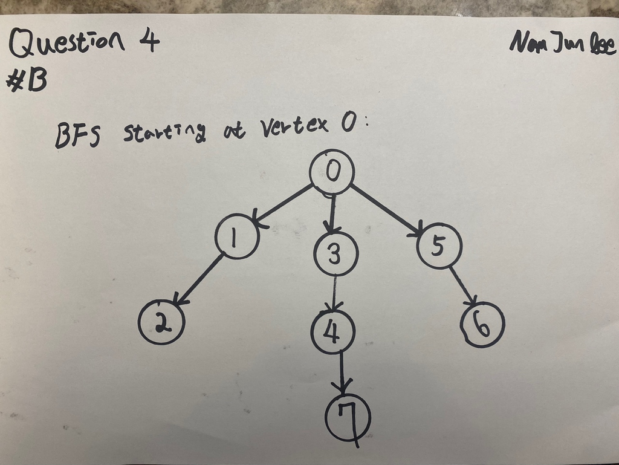

```python
Image("Q4-b.jpg")
```

C. Starting at vertex 0, show the depth-first search tree subgraph:

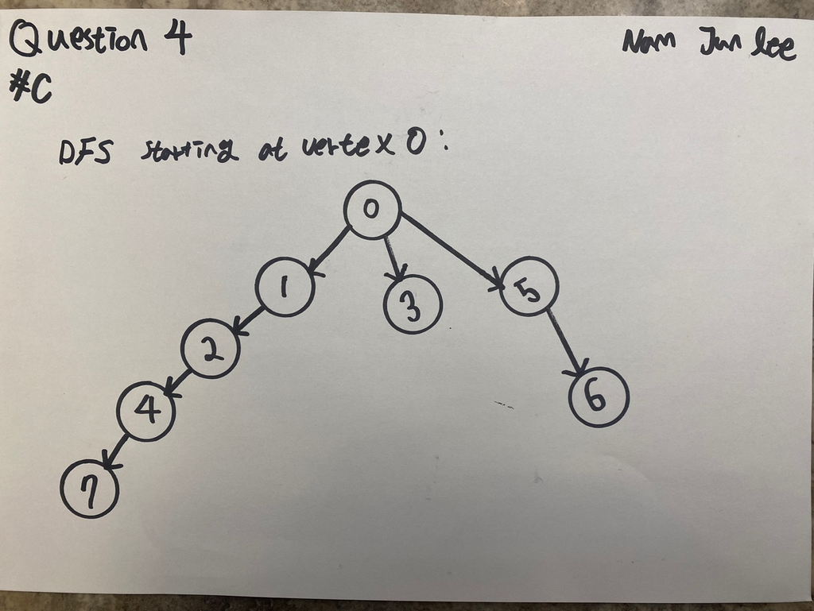

```python
Image("Q4-c.jpg")
```

5. (2 pts) What is the time complexity for breadth-first search and for depth-first search?

#### Question 5 Answer:

1. Time complexity for breadth-first search and for depth-first search: (V = vertices, E = edges)
- Breadth-first search:
  - Adjacency Matrix time complexity: $\mathcal{O}(V^2)$
  - Adjacency List time complexity: $\mathcal{O}(V+E)$
- Depth-first search:
  - Adjacency Matrix time complexity: $\mathcal{O}(V^2)$
  - Adjacency List time complexity: $\mathcal{O}(V+E)$

  The Breadth-first search time complexity is the same as the Death-first search time complexity.

6. (4 pts) For the following weighted digraph, find the shortest path from 0 to all other vertices.

[figure not shown]

#### Question 6 Answer:

Shortest path:

```
           | 0 |  1 | 2 | 3 | 4 | 5 | 6 | 7 |
         - | - |  - | - | - | - | - | - | - |
         0 | 0 |  0 | 0 | 0 | 0 | 0 | 0 | 0 |
         1 | 0 | 10 | 0 | 0 | 0 | 0 | 0 | 0 |
         2 | 0 |  0 | 25| 0 | 0 | 0 | 0 | 0 |
         3 | 0 |  0 | 0 | 30| 0 | 0 | 0 | 0 |
         4 | 0 |  0 | 0 | 0 | 30| 0 | 0 | 0 |
         5 | 0 |  0 | 0 | 0 | 0 | 20| 0 | 0 |
         6 | 0 |  0 | 0 | 0 | 0 | 0 | 25| 0 |
         7 | 0 |  0 | 0 | 0 | 0 | 0 | 0 | 40|

      [1]
      0 to 1: 10
      [2]
      0 to 1 to 2: 25
      [3]
      0 to 3: 30
      0 to 5 to 3: 30
      [4]
      0 to 1 to 2 to 4: 30
      0 to 3 to 4: 40
      0 to 5 to 3 to 4: 40
      [5]
      0 to 5: 20
      [6]
      0 to 5 to 6: 25
      [7]
      0 to 3 to 4 to 7: 40
      0 to 1 to 2 to 4 to 7: 40
      0 to 5 to 3 to 4 to 7: 50
      0 to 5 to 6 to 7: 40
```

Thus, shortest path from 0 to all other vertices:

**0 $\rightarrow$ 1 $\rightarrow$ 5 $\rightarrow$ 2 $\rightarrow$ 6 $\rightarrow$ 3 $\rightarrow$ 4 $\rightarrow$ 7**

### Implementation Question (20 pts)

#### Graph class

Implement an unweighted Graph using an **adjacency matrix** representation where the vertices are represented as rows and columns of a matrix and the edges are represented by the cells at the intersection of the row and column vertices.

As part of the implementation, define a list to store vertices and a 2-dimensional numpy array to store edges. Define methods to add and remove vertices and edges to the graphs, and print the string representation of the graph.

Below is the list of fields and methods to be defined for the implementation:

- `Graph` class:
  - Fields:
    - `self.vert_list`: list of all the vertices
    - `self.adj_matrix`: 2-dimensional matrix (numoy array) respresenting edges between the vertices.
  - Methods:
    - `__init__(self)`: initializes the vert_list to an empty list, the and adj_matrix to an empty 2-D numpy array.
    - `add_vertex(self, key)`: adds a vertex to the vert_list if it does not exist already. If the vertex exists in the vert_list, the list is not modified.
    - `add_edge(self, v1, v2)`: adds an edge of weight 1 between vertices v1 and v2, as well as v2 and v1 in the adj_matrix. If either vertex is not present in the vert_list, the vertex is added to the vert_list, and then the edge is added to the adj_matrix.
    - `__str__(self)`: retuns a string representation of the graph in the form:  
      (v1, v2)  
      (v1, v3)  
      ...  
      (vn, vn-1)  
      The string representation should only show the edges that are present in the graph.

**Note**: This implementation would be different than the one shown in lecture notes which is based on adjacency list representation.

#### Main program

Define and call a `main()` function that uses the Graph class definition to create a Graph object. Create vertices and edges of the graph using Graph object methods. Print graph information using its string representation.

Here is a summary of main() function:

- `main()` functipn:
  - create a graph object G
  - add sample data (vertices and edges) to the graph object G
  - print the string representation of the graph object G

You may use the sample data based on the graph shown below in your main function:

[figure not shown]

(image from https://upload.wikimedia.org/wikipedia/commons/thumb/5/5b/6n-graf.svg/640px-6n-graf.svg.png)

#### Implementation Question Answer:

Adjacency Matrix (from lecture notes):

```python
# a class representing a Vertex and using Graph class
class Vertex:
    def __init__(self, key):
        self.ID = key
        self.connected_to = {}
    # add connection from vertex to another
    def add_neighbor(self, neighbor, weight=0):
        self.connected_to[neighbor] = weight

    # return key
    def get_connections(self):
        return self.connected_to.keys()

    # return ID
    def get_ID(self):
        return self.ID

# a class representing a Graph
class Graph(object):
    '''
    contains a dictionary that maps vertex names to vertex objects.
    '''
    # initializes the vert_list and adj_matrix (2-D array)
    def __init__(self, size = 10):
        self.vert_list = {}
        self.num_vertices = 0
        self.adj_matrix = [[None] * size for _ in range(size)]

    # returns a string representation of output
    def __str__(self):
        edges = ""
        for vert in self.vert_list.values():
            for vert2 in vert.get_connections():
                edges += "(%s, %s)\n" %(vert.get_ID(), vert2.get_ID())
        return edges

    # add vertex to graph
    def add_vertex(self, key):
        self.num_vertices = self.num_vertices + 1
        new_vertex = Vertex(key)
        self.vert_list[key] = new_vertex
        return new_vertex

    def get_vertex(self, n):
        if n in self.vert_list:
            return self.vert_list[n]
        else:
            return None

    def __contains__(self, n):
        return n in self.vert_list

    # adds an edge of weight 1 between vertices in adj_matrix;
    # if vertex is not present in the vert_list then add.
    def add_edge(self, v1, v2):
        if v1 not in self.vert_list:
            self.add_vertex(v1)
        if v2 not in self.vert_list:
            self.add_vertex(v2)
        self.vert_list[v1].add_neighbor(self.vert_list[v2])
        self.adj_matrix[v1][v2] = 1
        self.adj_matrix[v2][v1] = 1

    # remove an edge in adj_matrix
    def remove_edge(self, v1, v2):
        if self.adj_matrix[v1][v2] == 0:
            print("No edge between %d & %d" % (v1, v2))
            return
        self.adj_matrix[v1][v2] = 0
        self.adj_matrix[v2][v1] = 0

    # return names of all vertices
    def get_vertices(self):
        return self.vert_list.keys()

    def __iter__(self):
        return iter(self.vert_list.values())
```

```python
# instance method
g = Graph()
# add vertex
for i in range(1, 7):
    g.add_vertex(i)

# add edge of weight 1 between 2 vertices
g.add_edge(1, 5)
g.add_edge(1, 2)
g.add_edge(2, 5)
g.add_edge(5, 4)
g.add_edge(2, 3)
g.add_edge(3, 4)
g.add_edge(4, 6)

# print output
print(g)
```

```
(1, 5)
(1, 2)
(2, 5)
(2, 3)
(3, 4)
(4, 6)
(5, 4)
```

## Submitting Assignments

1. Use the Blackboard tool https://learn.wsu.edu to submit your assignment. You will submit your code to the corresponding programming assignment under the "Content" tab. You must upload your solutions as `<your last name>_ma5.zip` by the due date and time.
2. Your .zip file should contain your .ipynb file and a .html file representing your Notebook as a webpage (File->Download as->HTML).

## Grading Guidelines

This assignment is worth 50 points. Your assignment will be evaluated based on a successful compilation and adherence to the program requirements. We will grade according to the following criteria:

- 28 pts for answering the conception questions
- 20 pts for correct implementation of the Graph using adjacency matrix representation
- 2 pts for for adherence to proper programming style and comments established for the class